# Prueba Practica

Alumno: Jhonny Maguana

#### Se buscar encontrar la eficiencia de la generación de números pseudo-aletorios a través de los métodos de cuadrados medios y congruencia lineal, para ello se debe seguir el siguiente proceso:

### 1. A traves de la misma api generar una semilla diferente.

```python
def semilla_congruencia(iteraciones):
    a = 11
    b = 15
    m = 13137
    xn_uno = 101

    tabla = []
    xna = xn_uno
    for i in range(1,iteraciones+1):
        numero = (a*xna+b)%m
        valor = numero/m
        tabla.append(round(valor*9000)+1000)
        xna = numero
    return tabla




def semilla_cuadra_medio(iteraciones):
    semilla_uno = 265987
    digitos = 5

    tabla = []
    xn = semilla_uno
    for i in range(iteraciones):
        cuadrado = xn**2
        numero = str(cuadrado)
        if (len(numero)%2 != digitos%2):
            numero = "0"+numero

        if (len(numero)<=digitos):
            Ui = cuadrado
        else:
            indice = int((len(numero)-digitos)/2)
            Ui = int(numero[indice:digitos+indice])
        valor = Ui/(10**digitos)

        tabla.append(round(valor*9000)+1000)

        xn = Ui
    return tabla
```

### 2. Encontrar el numero de iteraciones hasta que se repita uno de sus datos.

##### Congruencia Lineal

```python
a = 3
b = 10
m = 13137
xn = semilla_congruencia(1)[0]

tabla = []

xna = xn
while(True):
    numero = (a*xna+b)%m
    valor = numero/m
    resultado = round(valor*1000)
    if(resultado in tabla):
        print("Se repite: ",resultado)
        tabla.append(resultado)
        break

    tabla.append(resultado)
    xna = numero

print("en la iteración: ",len(tabla))
```

```
Se repite:  255
en la iteración:  42
```

##### Cuadrado Medio

```python
semilla = semilla_cuadra_medio(1)[0]
digitos = 5
iteraciones = 15
tabla = []
xn = semilla
while(True):
    cuadrado = xn**2
    numero = str(cuadrado)
    if (len(numero)%2 != digitos%2):
        numero = "0"+numero

    if (len(numero)<=digitos):
        Ui = cuadrado
    else:
        indice = int((len(numero)-digitos)/2)
        Ui = int(numero[indice:digitos+indice])
    valor = Ui/(10**digitos)

    resultado = round(valor*1000)
    if(resultado in tabla):
        print("Se repite: ",resultado)
        tabla.append(resultado)
        break

    tabla.append(resultado)
    xn = Ui

print("en la iteración: ",len(tabla))
```

```
Se repite:  106
en la iteración:  32
```

### 3. Generar 100 simulaciones con diferentes semillas.

##### Congruencia Lineal

```python
semillas = semilla_congruencia(100)
print(semillas)
```

```
[1771, 9496, 4464, 3112, 6244, 4691, 5607, 6682, 9514, 4660, 5267, 2952, 4480, 3293, 8233, 8575, 3335, 8700, 4715, 5870, 9583, 5428, 4723, 5961, 1578, 7371, 8087, 6970, 3679, 3476, 1245, 3708, 3800, 4810, 6918, 3106, 6176, 3945, 6400, 6409, 6507, 7584, 1438, 5833, 9177, 9952, 9483, 4321, 1537, 6918,…
```

```python
a = 13
b = 23
m = 13137
tablacl = []
for i in semillas:

    tabla_aux = []

    xna = i
    while(True):
        numero = (a*xna+b)%m
        valor = numero/m
        resultado = round(valor*1000)
        if(resultado in tabla_aux):
            tabla_aux.append(resultado)
            break

        tabla_aux.append(resultado)
        xna = numero
    tablacl.append(len(tabla_aux))

print(tablacl)
```

```
[16, 21, 44, 36, 38, 44, 24, 26, 2, 26, 17, 42, 57, 40, 88, 72, 9, 56, 11, 40, 22, 65, 14, 40, 18, 10, 54, 48, 57, 70, 45, 23, 47, 29, 27, 26, 59, 46, 45, 70, 50, 151, 44, 28, 32, 32, 63, 26, 49, 27, 41, 79, 7, 48, 21, 64, 55, 151, 47, 41, 31, 12, 19, 64, 24, 37, 58, 59, 19, 24, 52, 4, 41, 31, 35, 5…
```

##### Cuadrado Medio

```python
semillascm = semilla_cuadra_medio(100)
print(semillascm)
```

```
[5418, 1832, 5823, 7480, 8495, 4200, 6793, 4926, 1283, 8736, 9021, 4830, 1960, 4502, 2294, 7028, 8781, 7686, 2764, 4673, 6935, 5387, 7829, 6200, 4405, 3834, 2288, 5324, 1766, 3239, 9158, 2421, 9392, 9450, 2278, 2604, 7797, 1349, 5507, 1703, 1840, 7445, 3493, 7810, 3335, 3969, 8933, 7211, 6639, 3320,…
```

```python
digitos = 5
iteraciones = 15
tablacm = []

for i in semillascm:
    xn = i
    tabla_aux = []
    while(True):
        cuadrado = xn**2
        numero = str(cuadrado)
        if (len(numero)%2 != digitos%2):
            numero = "0"+numero

        if (len(numero)<=digitos):
            Ui = cuadrado
        else:
            indice = int((len(numero)-digitos)/2)
            Ui = int(numero[indice:digitos+indice])
        valor = Ui/(10**digitos)

        resultado = round(valor*1000)
        if(resultado in tabla_aux):
            tabla_aux.append(resultado)
            break

        tabla_aux.append(resultado)
        xn = Ui
    tablacm.append(len(tabla_aux))

print(tablacm)
```

```
[32, 65, 70, 15, 54, 27, 19, 31, 12, 47, 42, 72, 12, 23, 32, 81, 60, 74, 14, 32, 22, 47, 58, 12, 64, 25, 46, 49, 38, 18, 31, 4, 44, 23, 62, 22, 75, 54, 43, 47, 16, 35, 54, 27, 55, 25, 12, 30, 33, 38, 14, 54, 88, 48, 10, 47, 22, 56, 7, 21, 49, 27, 29, 29, 31, 33, 45, 44, 30, 54, 37, 5, 28, 28, 35, 18…
```

### 4. Generar un histograma con el resultado obtenidos por cada método.

##### Congruencia Lineal

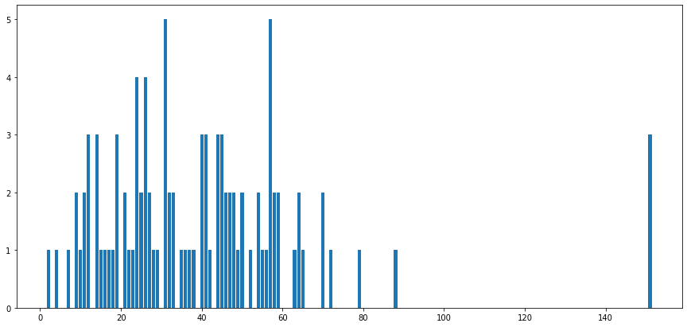

```python
import numpy as np
import matplotlib.pyplot as pp

tablacl.sort()
contador = 1
x=[]
y=[]
for i in range(len(tablacl)-1):
    if(tablacl[i]==tablacl[i+1]):
        contador+=1
    else:
        y.append(tablacl[i])
        x.append(contador)
        contador = 1
y.append(tablacl[-1])
x.append(contador)
pp.figure(figsize=(15,7))

pp.bar(y,x)
pp.show()
```

##### Cuadrado Medio

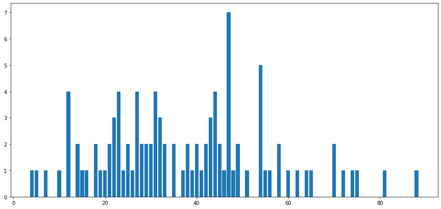

```python
import numpy as np
import matplotlib.pyplot as pp

tablacm.sort()
contador = 1
x=[]
y=[]
for i in range(len(tablacm)-1):
    if(tablacm[i]==tablacm[i+1]):
        contador+=1
    else:
        y.append(tablacm[i])
        x.append(contador)
        contador = 1

y.append(tablacm[-1])
x.append(contador)
pp.figure(figsize=(15,7))
pp.bar(y,x)
pp.show()
```

### 5. Agregar sus conclusiones, opiniones y recomendaciones

Esto demuestra que el metodo de la congruencia lineal a pesar de ser un metodo mas sencillo de implementar tiene mejores resultados en variedad de numero generados.

Para realizar esta demostración se recomienda limitar el rango de generación de nueros intentos, con esto aseguramos el resultado acorde con la realidad de la efectividadd de los metodos.